# HW2_Q2_401204354

### Deep Learning HW2

### Fine-tuning Resnet

**Name:** Javad Razi Giglou

**Std. No.:** 401204354

```python
import torch
import torchvision
from torch.autograd import Variable
import torch.nn as nn
from torch.utils.data import DataLoader
from torchvision import models
import torchvision.transforms as transforms
from torchvision import datasets
import torch.optim as optim
import matplotlib.pyplot as plt
! pip install explainable-cnn
```

## Data Preparation

```python
# Define the transformations to apply to the images
train_transform = transforms.Compose([
    transforms.RandomResizedCrop(224),
    transforms.RandomHorizontalFlip(),
    transforms.ToTensor(),
    transforms.Normalize(mean=[0.485, 0.456, 0.406], std=[0.229, 0.224, 0.225])
])

test_transform = transforms.Compose([
    transforms.Resize(256),
    transforms.CenterCrop(224),
    transforms.ToTensor(),
    transforms.Normalize(mean=[0.485, 0.456, 0.406], std=[0.229, 0.224, 0.225])
])
```

```python
from torchvision.datasets import CIFAR10

batch_size = 64
num_classes = 10

########################## TODO ##########################
# Download CIFAR10 dataset
train_dataset = CIFAR10(root='./data_q2', train=True, download=True, transform=train_transform)
test_dataset = CIFAR10(root='./data_q2', train=False, download=True, transform=test_transform)
####################### (5 points) #######################

########################## TODO ##########################
# Create data loaders for the train and test datasets
# In this homework, we use the test dataset as the validation dataset

train_loader = DataLoader(dataset=train_dataset, batch_size=batch_size, shuffle=True)
test_loader = DataLoader(dataset=test_dataset, batch_size=batch_size, shuffle=False)
####################### (5 points) #######################
```

```
Downloading https://www.cs.toronto.edu/~kriz/cifar-10-python.tar.gz to ./data_q2/cifar-10-python.tar.gz
```

```
Extracting ./data_q2/cifar-10-python.tar.gz to ./data_q2
Files already downloaded and verified
```

## Model

```python
class Model(nn.Module):
    def __init__(self, num_classes, freeze=False):
        super(Model, self).__init__()

        ########################## TODO ##########################
        # Initialize a ResNet-50 torchvision model with pre-trained weights
        # Modify the last layer of the model (model.fc) and replace it with
        # a sequence of multiple linear layers according to the following structure:
        # model.fc.in_features -> 128 -> 64 -> 32 -> num_classes
        # Use ReLU activation functions between linear layers and LogSoftmax at the end

        self.model = torchvision.models.resnet50(pretrained=True)
        layers = [
            nn.Linear(self.model.fc.in_features, 128),
            nn.ReLU(),
            nn.Linear(128, 64),
            nn.ReLU(),
            nn.Linear(64, 32),
            nn.ReLU(),
            nn.Linear(32, num_classes),
            nn.LogSoftmax(dim=1)
        ]
        self.model.fc = nn.Sequential(*layers)
        ####################### (20 points) ######################

        ########################## TODO ##########################
        # if freeze flag is true, freeze all model parameters except for the fc layers
        if freeze:
            for param in self.model.parameters():
                param.requires_grad = False
            for param in self.model.fc.parameters():
                param.requires_grad = True
        ####################### (5 points) #######################

    def forward(self, x):
        return self.model(x)
```

```python
def train(model, epoch, optimizer, train_loader, criterion=nn.CrossEntropyLoss()):
    # Initialize the running loss and accuracy
    total_loss = 0
    correct = 0
    total_size = 0

    ########################## TODO ##########################
    # Set the model to train mode
    model.train()
    ####################### (5 points) #######################

    # Iterate over the batches of the train loader
    for batch_idx, (data, target) in enumerate(train_loader):
        ########################## TODO ##########################
        # Move the data and target to the device
        data, target = data.to(device), target.to(device)
        ####################### (5 points) #######################

        # Zero the optimizer gradients
        optimizer.zero_grad()
        # Forward pass
        output = model(data)
        loss = criterion(output, target)
        # Update the running loss
        total_loss += loss.item()
        total_size += data.size(0)

        ########################## TODO ##########################
        # Update correct variable based on model output and target
        _, predicted = output.max(1)
        correct += predicted.eq(target).sum().item()
        ####################### (10 points) ######################

        # Backward pass and optimizer step
        loss.backward()
        optimizer.step()

        if batch_idx % 100 == 0:
            print('Train Epoch: {} [{}/{} ({:.0f}%)]\tAverage loss: {:.6f}'.format(
                epoch, batch_idx * len(data), len(train_loader.dataset),
                100. * batch_idx / len(train_loader), total_loss / total_size))

    return total_loss / total_size, 100. * correct / len(train_loader.dataset)

def test(model, test_loader, criterion=nn.CrossEntropyLoss()):
    ########################## TODO ##########################
    # Set the model to evaluation mode
    model.eval()
    ####################### (5 points) #######################

    # Initialize the running loss and accuracy
    test_loss = 0
    correct = 0
    # Iterate over the batches of the validation loader
    with torch.no_grad():
        for data, target in test_loader:
            ########################## TODO ##########################
            # Move the data and target to the device
            data, target = data.to(device), target.to(device)
            ####################### (0 points) #######################
            # Forward pass
            output = model(data)
            loss = criterion(output, target)
            # Update the running loss and accuracy
            test_loss += loss.item()

            ########################## TODO ##########################
            # Update correct variable based on model output and target
            _, predicted = output.max(1)
            correct += predicted.eq(target).sum().item()
            ####################### (0 points) #######################

    # Calculate the validation loss and accuracy
    test_loss /= len(test_loader.dataset)
    print('\nTest set: Average loss: {:.4f}, Accuracy: {}/{} ({:.0f}%)\n'.format(
        test_loss, correct, len(test_loader.dataset),
        100. * correct / len(test_loader.dataset)))

    return test_loss, 100. * correct / len(test_loader.dataset)
```

```python
model_1 = Model(num_classes, freeze=False)
model_2 = Model(num_classes, freeze=True)
model_1
```

```
Model(
  (model): ResNet(
    (conv1): Conv2d(3, 64, kernel_size=(7, 7), stride=(2, 2), padding=(3, 3), bias=False)
    (bn1): BatchNorm2d(64, eps=1e-05, momentum=0.1, affine=True, track_running_stats=True)
    (relu): ReLU(inplace=True)
    (maxpool): MaxPool2d(kernel_size=3, stride=2, padding=1, dilation=1, ceil_mode=False)
    (layer1): Sequential(
      (0): Bottleneck(
        (conv1): Conv2d(64, 64, kernel_size=(1, 1), stride=(1, 1), bias=False)
        (bn1): BatchNorm2d(64, eps=1e-05, momentum=0.1, affine=True, track_running_stats=True)
        (conv2): Conv2d(64, 64, kernel_size=(3, 3), stride=(1, 1), padding=(1, 1), bias=False)
        (bn2): BatchNorm2d(64, eps=1e-05, momentum=0.1, affine=True, track_running_stats=True)
        (conv3): Conv2d(64, 256, kernel_size=(1, 1), stride=(1, 1), bias=False)
        (bn3): BatchNorm2d(256, eps=1e-05, momentum=0.1, affine=True, track_running_stats=True)
        (relu): ReLU(inplace=True)
        (downsample): Sequential(
          (0): Conv2d(64, 256, kernel_size=(1, 1), stride=(1, 1), bias=False)
          (1): BatchNorm2d(256, eps=1e-05, momentum=0.1, affine=True, track_running_stats=True)
        )
      )
      (1): Bottleneck(
        (conv1): Conv2d(256, 64, kernel_size=(1, 1), stride=(1, 1), bias=False)
        (bn1): BatchNorm2d(64, eps=1e-05, momentum=0.1, affine=True, track_running_stats=True)
        (conv2): Conv2d(64, 64, kernel_size=(3, 3), stride=(1, 1), padding=(1, 1), bias=False)
        (bn2): BatchNorm2d(64, eps=1e-05, momentum=0.1, affine=True, track_running_stats=True)
        (conv3): Conv2d(64, 256, kernel_size=(1, 1), stride=(1, 1), bias=False)
        (bn3): BatchNorm2d(256, eps=1e-05, momentum=0.1, affine=True, track_running_stats=True)
        (relu): ReLU(inplace=True)
      )
      (2): Bottleneck(
        (conv1): Conv2d(256, 64, kernel_size=(1, 1), stride=(1, 1), bias=False)
        (bn1): BatchNorm2d(64, eps=1e-05, momentum=0.1, affine=True, track_running_stats=True)
        (conv2): Conv2d(64, 64, kernel_size=(3, 3), stride=(1, 1), padding=(1, 1), bias=False)
        (bn2): BatchNorm2d(64, eps=1e-05, momentum=0.1, affine=True, track_running_stats=True)
        (conv3): Conv2d(64, 256, kernel_size=(1, 1), stride=(1, 1), bias=False)
        (bn3): BatchNorm2d(256, eps=1e-05, momentum=0.1, affine=True, track_running_stats=True)
        (relu): ReLU(inplace=True)
      )
    )
    (layer2): Sequential(
```

[output cut: 132 more lines]

```
      )
    )
    (avgpool): AdaptiveAvgPool2d(output_size=(1, 1))
    (fc): Sequential(
      (0): Linear(in_features=2048, out_features=128, bias=True)
      (1): ReLU()
      (2): Linear(in_features=128, out_features=64, bias=True)
      (3): ReLU()
      (4): Linear(in_features=64, out_features=32, bias=True)
      (5): ReLU()
      (6): Linear(in_features=32, out_features=10, bias=True)
      (7): LogSoftmax(dim=1)
    )
  )
)
```

## Training

```python
########################## TODO ##########################
# Run the following code for each of the above models
# Based on your resources you can choose number of epochs from 3 to 5
####################### (10 points) #######################
model = model_1
num_epochs = 5
# Set the device
device = 'cuda' if torch.cuda.is_available() else 'cpu'
# Define loss function and optimizer
criterion = torch.nn.CrossEntropyLoss()
optimizer = optim.SGD(model.parameters(), lr=0.001, momentum=0.9)
model = model.to(device)

####   Train Model
# Initialize variables for early stopping
early_stopping_threshold = 3
epochs_no_improve = 0
early_stop = False
best_val_acc = 0

for epoch in range(1, num_epochs + 1):
    train_loss, train_acc = train(model, epoch, optimizer, train_loader, criterion)
    val_loss, val_acc = test(model, test_loader, criterion)

    ########################## TODO ##########################
    # Check early stopping
    if val_acc > best_val_acc:
        # Update best validation accuracy and reset the counter
        best_val_acc = val_acc
        epochs_no_improve = 0
    else:
        # Increment the counter when validation accuracy doesn't improve
        epochs_no_improve += 1

    if epoch > 3 and epochs_no_improve == early_stopping_threshold:
        print('Early stopping!')
        early_stop = True
        break

    ####################### (10 points) #######################
```

```
Train Epoch: 1 [0/50000 (0%)]	Average loss: 0.036210
Train Epoch: 1 [6400/50000 (13%)]	Average loss: 0.036020
Train Epoch: 1 [12800/50000 (26%)]	Average loss: 0.035947
Train Epoch: 1 [19200/50000 (38%)]	Average loss: 0.035811
Train Epoch: 1 [25600/50000 (51%)]	Average loss: 0.035575
Train Epoch: 1 [32000/50000 (64%)]	Average loss: 0.035011
Train Epoch: 1 [38400/50000 (77%)]	Average loss: 0.034038
Train Epoch: 1 [44800/50000 (90%)]	Average loss: 0.032940

Test set: Average loss: 0.0195, Accuracy: 5705/10000 (57%)

Train Epoch: 2 [0/50000 (0%)]	Average loss: 0.020880
Train Epoch: 2 [6400/50000 (13%)]	Average loss: 0.021614
Train Epoch: 2 [12800/50000 (26%)]	Average loss: 0.020334
Train Epoch: 2 [19200/50000 (38%)]	Average loss: 0.019115
Train Epoch: 2 [25600/50000 (51%)]	Average loss: 0.018075
Train Epoch: 2 [32000/50000 (64%)]	Average loss: 0.017099
Train Epoch: 2 [38400/50000 (77%)]	Average loss: 0.016366
Train Epoch: 2 [44800/50000 (90%)]	Average loss: 0.015712

Test set: Average loss: 0.0049, Accuracy: 8973/10000 (90%)

Train Epoch: 3 [0/50000 (0%)]	Average loss: 0.010877
Train Epoch: 3 [6400/50000 (13%)]	Average loss: 0.010629
Train Epoch: 3 [12800/50000 (26%)]	Average loss: 0.010289
Train Epoch: 3 [19200/50000 (38%)]	Average loss: 0.010189
Train Epoch: 3 [25600/50000 (51%)]	Average loss: 0.009995
Train Epoch: 3 [32000/50000 (64%)]	Average loss: 0.009875
Train Epoch: 3 [38400/50000 (77%)]	Average loss: 0.009731
Train Epoch: 3 [44800/50000 (90%)]	Average loss: 0.009621

Test set: Average loss: 0.0033, Accuracy: 9277/10000 (93%)

Train Epoch: 4 [0/50000 (0%)]	Average loss: 0.013005
Train Epoch: 4 [6400/50000 (13%)]	Average loss: 0.008720
Train Epoch: 4 [12800/50000 (26%)]	Average loss: 0.008523
Train Epoch: 4 [19200/50000 (38%)]	Average loss: 0.008379
Train Epoch: 4 [25600/50000 (51%)]	Average loss: 0.008273
Train Epoch: 4 [32000/50000 (64%)]	Average loss: 0.008213
Train Epoch: 4 [38400/50000 (77%)]	Average loss: 0.008169
Train Epoch: 4 [44800/50000 (90%)]	Average loss: 0.008097

Test set: Average loss: 0.0026, Accuracy: 9415/10000 (94%)

Train Epoch: 5 [0/50000 (0%)]	Average loss: 0.005773
Train Epoch: 5 [6400/50000 (13%)]	Average loss: 0.007560
Train Epoch: 5 [12800/50000 (26%)]	Average loss: 0.007589
Train Epoch: 5 [19200/50000 (38%)]	Average loss: 0.007487
Train Epoch: 5 [25600/50000 (51%)]	Average loss: 0.007517
Train Epoch: 5 [32000/50000 (64%)]	Average loss: 0.007509
Train Epoch: 5 [38400/50000 (77%)]	Average loss: 0.007498
Train Epoch: 5 [44800/50000 (90%)]	Average loss: 0.007391

Test set: Average loss: 0.0024, Accuracy: 9468/10000 (95%)
```

### GradCam

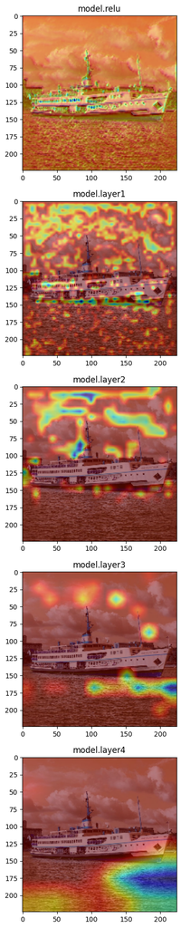

```python
from explainable_cnn import CNNExplainer

classes_name = {
                0: 0, # "airplane"
                1: 1, # "automobile"
                2: 2, # "bird"
                3: 3, # "cat"
                4: 4, # "deer"
                5: 5,  # "dog"
                6: 6, # "frog"
                7: 7, # "horse"
                8: 8, # "ship"
                9: 9 # "truck"
}
layers = ["model.relu", "model.layer1", "model.layer2", "model.layer3", "model.layer4"]
x_cnn = CNNExplainer(model_1, classes_name)

########################## TODO ##########################
# Pick a picture of your choice and Run the following code with your trained model_1

grad_cam = x_cnn.get_grad_cam(
    './ship.jpg',
    8,
    (224, 224),
    layers
)
####################### (5 points) #######################

fig, axs = plt.subplots(len(layers), figsize=(10, 24))
# Note that get_grad_cam() returns list of images (numpy array)
for i in range(0, len(layers)):
  axs[i].set_title(layers[i])
  axs[i].imshow(grad_cam[i].astype('uint8'))
```

#### Explain about one advantage and one limitation of using Grad-CAM (Gradient-weighted Class Activation Mapping) as a method for explaining the predictions of Convolutional Neural Networks (CNNs) (15 point)

**Advantage:** Grad-CAM provides a visual explanation of which parts of the image were important for a Convolutional Neural Network's (CNN's) prediction. In the image we've generated, we can see different heatmaps for each layer of the CNN. The heatmaps highlight the regions in the image that the CNN focused on to make its prediction. This is a major advantage of Grad-CAM as it helps us understand the decision-making process of the CNN. For instance, the model seems to detect the object as a ship by focusing on detecting the sea.

**Limitation:** Despite its advantages, Grad-CAM has some limitations. One of the main limitations is that it sometimes highlights regions of an image that the model did not actually use for prediction. This makes Grad-CAM an unreliable model explanation method. For example, in the image we've generated, if there are highlighted regions that don't seem to correspond to the object of interest (in this case, a ship), it could be a demonstration of this limitation. Additionally, its performance drops when localizing multiple occurrences of the same class.